# WEEK 13 Part2 IP R PROGRAMMING

## Hierachical clustering

```r
# First we use the dist() function to compute the Euclidean distance between observations,
# d will be the first argument in the hclust() function dissimilarity matrix
# ---
#
d <- dist(ec.encod, method = "euclidean")

# We then hierarchical clustering using the Ward's method
# ---
#
res.hc <- hclust(d, method = "ward.D2" )
res.hc
```

```
##
## Call:
## hclust(d = d, method = "ward.D2")
##
## Cluster method   : ward.D2
## Distance         : euclidean
## Number of objects: 12199
```

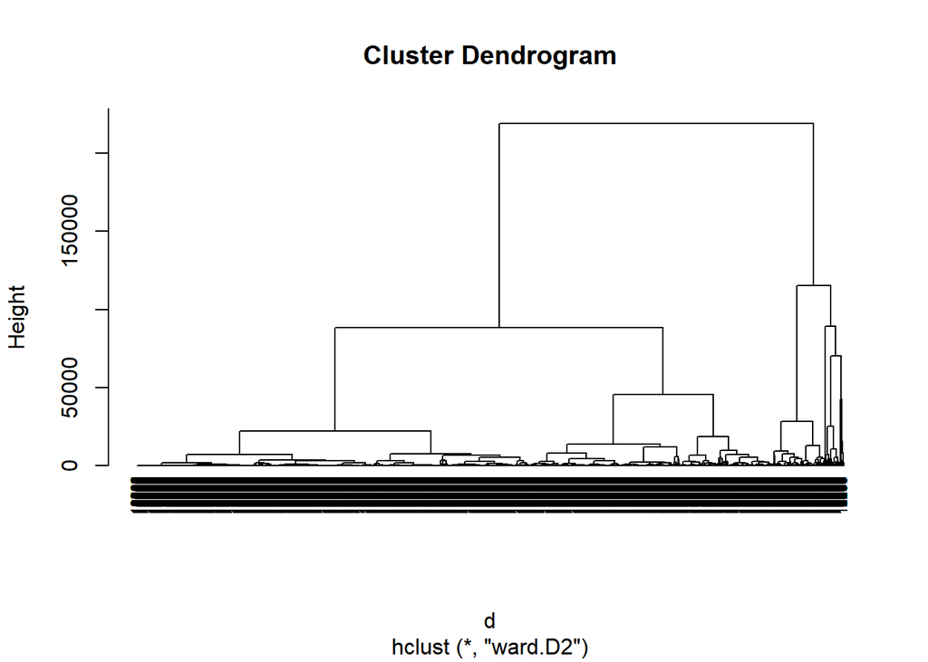

```r
# plotting the obtained dendrogram
# ---
#
plot(res.hc, cex = 0.6, hang = -1)
```

#8. Challenging the solution

```r
#we'll use dbscan
library('dbscan')

# Applying our DBSCAN algorithm
# We want minimum 4 points with in a distance of eps(0.4)
#
db<-dbscan(ec.encod,eps=0.4,MinPts = 4)
db
```

```
## DBSCAN clustering for 12199 objects.
## Parameters: eps = 0.4, minPts = 4
## The clustering contains 1 cluster(s) and 12195 noise points.
##
##     0     1
## 12195     4
##
## Available fields: cluster, eps, minPts
```

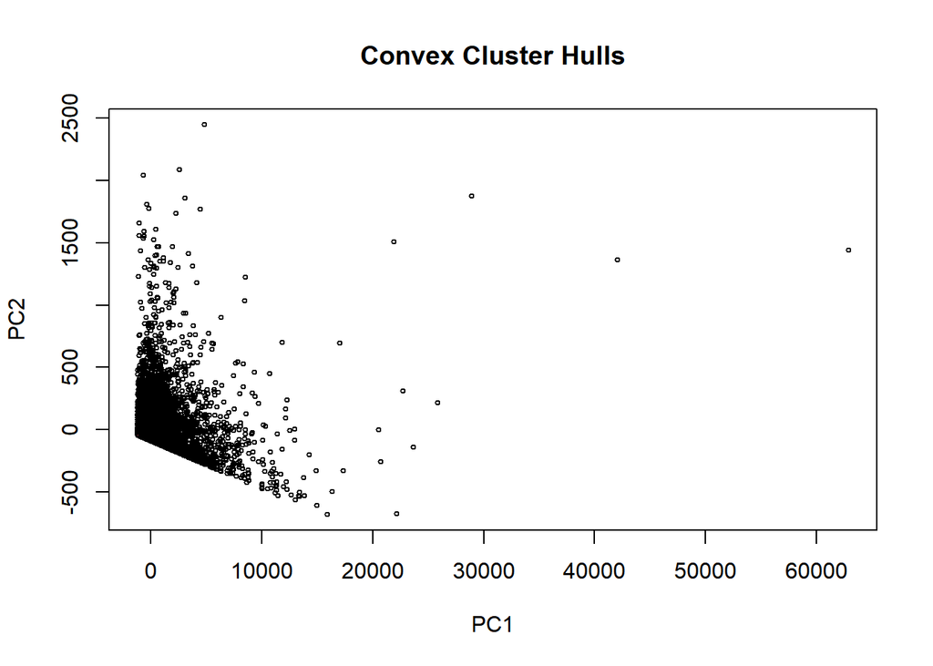

```r
# plotting our clusters as shown
#
hullplot(ec.encod,db$cluster)
```

### Conclusion

- Kmeans performed better than hierachical clustering in this study as it can handle larger datasets as compared to hierachical clustering.
- DBSCAN performsed poorly compared to Kmeans clustering.

### Recommendations

- I’d recommend more resources to be allocated to marketing the brand on the weekends as the revenue generated is lower that that of weekdays.
- As seen from the study weekdays, region 1, returning visitors generate the most revenue. The company should consider looking into exploring these features further to maximize the income brought in.
- I’d recommed the use of Kmeans clustering as it can handle large datasets better that hierachial clustering.

##9. Follow up questions

###a) Did we have the right data? `Yes we did. Our data set had a good number of variables that helped us study the individuals and determine who was likely to finish an ecommerce transaction.`

###b) Do we need other data to answer our question? `Not necessarily, however further research is needed to help gain deeper insight on the study.`

###c) Did we have the right question? `Classifying customers by studying and understanding their behavior from data collected over the past year while also learning the characteristics of customer groups. We were able to do that by analysing the given dataset.`